# VPC - meropenem PK model

Metrum Research Group

```r
source("../src/global.R")
source("../src/functions.R")
library(tidyverse)
library(mrgsolve)
library(data.table)
library(furrr)
Sys.setenv(R_FUTURE_FORK_ENABLE=TRUE)
future::plan(future::multiprocess)


.colSet1 <- function(x,...) scale_color_brewer(palette = "Set1", ...)
.fillSet1 <- function(x,...) scale_fill_brewer(palette = "Set1", ...)
```

# 1 Introduction

- “Population Pharmacokinetic Analysis and Dosing Regimen Optimization of Meropenem in Adult Patients”
  - Li et al. J Clin Pharmacol 2006
- Meropenem is broad-spectrum carbapenem antibiotic
  - Efficacy related to time above MIC
- IV dosing every 8 hours by infusion or bolus
  - bolus over 3 to 5 minutes
  - infusion over 15 to 30 minutes
- Authors are interested in seeing if a longer infusion duration can increase time above MIC

# 2 Helper functions

```r
qt <- function(x,y) unname(quantile(x,prob=y/100))
lo <- function(x) qt(x,5)
hi <- function(x) qt(x,95)
med <- function(x) qt(x,50)
loci <- function(x) qt(x,2.5)
hici <- function(x) qt(x,97.5)
col1 <- "steelblue"
col2 <- "firebrick"
```

# 3 Read and fix up the data set

```r
data <-
  read_csv("../data/Simulated_DatasetMeropenem.csv", na = '.')  %>%
  mutate(CMT=1, DUR = AMT/RATE)
```

Derive a column that describes the infusion duration for each subject

```r
data %<>%
  group_by(ID) %>%
  mutate(DUR = first(DUR[!is.na(AMT)])) %>%
  ungroup

data <- data %>% mutate(DUR = round(DUR,1))
```

Look at distinct values of `CMT`, `EVID`, `DUR` in `data`

```r
count(data,CMT,EVID,DUR)
```

```
. # A tibble: 4 x 4
.     CMT  EVID   DUR     n
.   <dbl> <dbl> <dbl> <int>
. 1     1     0   0.5   280
. 2     1     0   3     273
. 3     1     1   0.5    40
. 4     1     1   3      39
```

Derive two data frames

- One with observations only
- One with doses only

```r
obs <- filter(data, EVID==0)

head(obs)
```

```
. # A tibble: 6 x 13
.      ID  TIME GROUP     DV   MDV  EVID   AMT  RATE   AGE    WT  CLCR   CMT
.   <dbl> <dbl> <dbl>  <dbl> <dbl> <dbl> <dbl> <dbl> <dbl> <dbl> <dbl> <dbl>
. 1     1   0.5     1 31.1      NA     0    NA    NA  29.7  63.8    83     1
. 2     1   1       1 11.2      NA     0    NA    NA  29.7  63.8    83     1
. 3     1   2       1  6.21     NA     0    NA    NA  29.7  63.8    83     1
. 4     1   3       1  4.00     NA     0    NA    NA  29.7  63.8    83     1
. 5     1   4       1  2.33     NA     0    NA    NA  29.7  63.8    83     1
. 6     1   6       1  0.766    NA     0    NA    NA  29.7  63.8    83     1
. # … with 1 more variable: DUR <dbl>
```

```r
dose <- filter(data, EVID==1)
```

Plot observed data

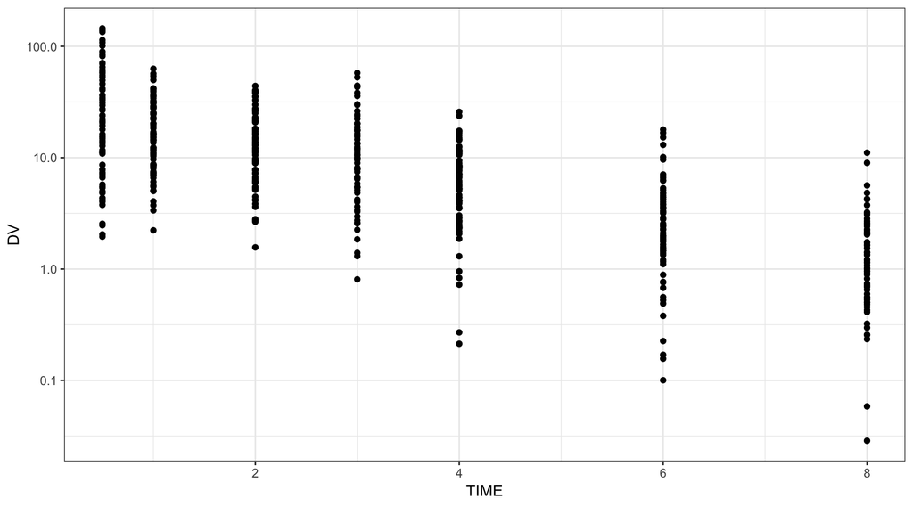

```r
ggplot(data=obs, aes(TIME,DV)) +
  geom_point() +
  scale_y_log10()
```

Plot observed data by `DUR`

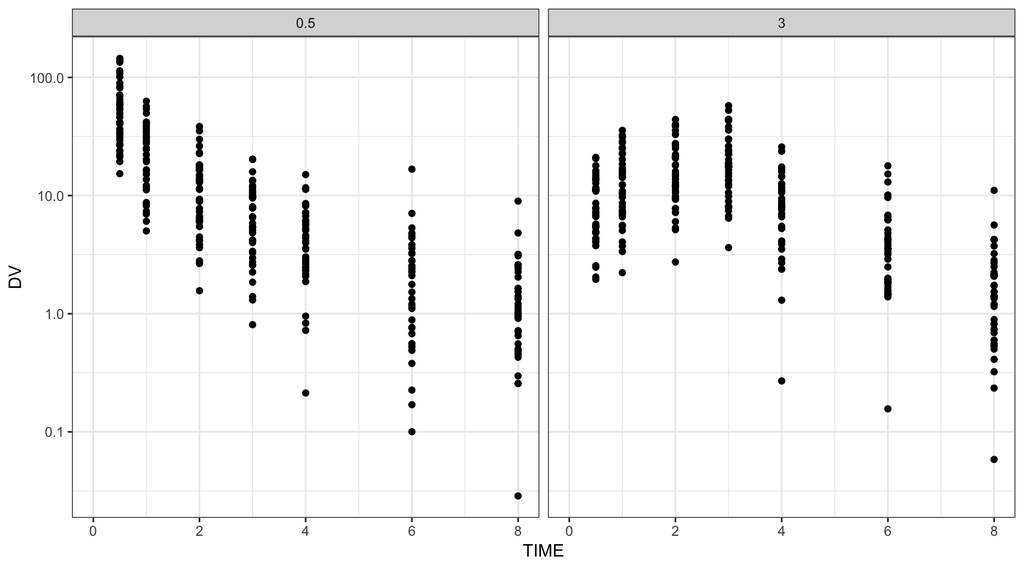

```r
ggplot(data=obs, aes(TIME,DV)) +
  geom_point() +
  scale_y_log10() +
  facet_wrap(~DUR) + xlim(0,8)
```

# 4 Load the meropenem model

```r
mod <- mread("meropenem", "../model")
see(mod)
```

```
.
. Model file:  meropenem.cpp
. [PROB]
. Meropenem PopPK
.
. https://www.ncbi.nlm.nih.gov/pubmed/16988206
.
. [SET] delta=0.1, end=8, req=""
.
. [PKMODEL] cmt = "CENT, PERIPH"
.
. [PARAM] @annotated
. WT   : 70 : Weight (kg)
. CLCR : 83 : Creatinine clearance (ml/min)
. AGE  : 35 : Age (years)
.
. [THETA] @annotated
.  1.50E+01 : Typical value of clearance (L/h)
.  1.27E+01 : Typical value of volume 1 (L)
.  1.52E+01 : Intercompartmental clearance (L/h)
.  1.24E+01 : Typical value of volume 2 (L)
. -4.47E-01 : AGE on CL
.  8.20E-01 : WT on V1
.  1.88E-01 : Proportional error standard deviation
.  4.76E-01 : Additive error standard deviation
.  6.20E-01 : CLCR on CL
.
. [MAIN]
.
. double TVCL     = THETA1;
. double TVV1     = THETA2;
. double TVQ      = THETA3;
. double TVV2     = THETA4;
. double CL_AGE   = THETA5;
. double V1_WT    = THETA6;
. double RUV_PROP = THETA7;
. double RUV_ADD  = THETA8;
. double CL_CLCR  = THETA9;
.
. double LOGTWT = log((WT/70.0));
```

[output cut: 12 more lines]

```
.
. [OMEGA] @annotated
. ECL : 8.84E-02 : ETA on CL
. EV1 : 9.76E-02 : ETA on V1
. EQ  : 1.03E-01 : ETA on Q
. EV2 : 7.26E-02 : ETA on V2
.
. [SIGMA] @annotated
. EP : 1 : Not used
.
. [TABLE]
. capture CC = (CENT/V1);
. double IPRED = CC;
. double W = sqrt((RUV_ADD*RUV_ADD)+ (RUV_PROP*RUV_PROP*IPRED*IPRED));
. capture Y = IPRED+W*EPS(1);
```

This model looks a little different because we got it off of DDMoRe model repository.

# 5 Set up a simulation time grid for the VPC

```r
des1 <- tgrid(end = 3.2, delta = 0.2, add=0.05)
des2 <- tgrid(0,8,2)
des <- c(des1,des2)
des
```

```
. start:  0  end:    3.2  delta:  0.2  offset: 0  min:    0   max:    3.2
. --------
. start:  0  end:    8  delta:  2  offset: 0  min:    0   max:    8
. --------
```

A function to do the (replicate) simulation

Arguments

- `i` the replicate number

Returns simulated data set

- time as in `des`
- `DUR` the infusion duration
- `TIME > 0` and `Y > 0`
- Labeled with replicate number

```r
simvpc <- function(i) {
  mod %>%
    carry_out(DUR) %>%
    obsonly %>%
    mrgsim_d(dose,tgrid=des) %>%
    filter(TIME > 0 & Y > 0) %>%
    mutate(irep = i)
}
```

Simulate

```r
niter <- 300
out <- future_map_dfr(seq(niter), simvpc)
```

# 6 Summarize simulated data

```r
sum1 <-
  out %>%
  group_by(DUR,irep,TIME) %>%
  summarise(med=med(Y), lo=lo(Y), hi=hi(Y), N=n()) %>%
  ungroup
```

```r
sumdt <- as.data.table(out)

sumry <- function(x) {
  setNames(quantile(x, probs=c(0.5, 0.05, 0.95)),c("med", "lo", "hi"))
}

sum1 <- sumdt[, as.list(sumry(Y)), by = "irep,DUR,TIME"]

head(sum1)
```

```
.    irep DUR TIME       med        lo        hi
. 1:    1 0.5 0.05  7.975549  2.174776  22.50789
. 2:    1 0.5 0.20 24.946053  7.639629  76.69965
. 3:    1 0.5 0.40 40.865735 10.810578  97.35159
. 4:    1 0.5 0.60 43.379750 15.723748 100.29410
. 5:    1 0.5 0.80 23.295113  7.100784  59.05131
. 6:    1 0.5 1.00 22.908566  6.633021  50.10997
```

gather

```r
sum1g <- gather(sum1, metric, value, med:hi, factor_key=TRUE)

head(sum1g)
```

```
.   irep DUR TIME metric     value
. 1    1 0.5 0.05    med  7.975549
. 2    1 0.5 0.20    med 24.946053
. 3    1 0.5 0.40    med 40.865735
. 4    1 0.5 0.60    med 43.379750
. 5    1 0.5 0.80    med 23.295113
. 6    1 0.5 1.00    med 22.908566
```

```r
sum2 <-
  sum1g %>%
  group_by(DUR,TIME,metric) %>%
  summarise(
    med = median(value), lo = loci(value), hi = hici(value)
) %>% ungroup

head(sum2)
```

```
. # A tibble: 6 x 6
.     DUR  TIME metric   med    lo    hi
.   <dbl> <dbl> <fct>  <dbl> <dbl> <dbl>
. 1   0.5  0.05 med     7.28  6.06  8.91
. 2   0.5  0.05 lo      2.62  1.76  3.48
. 3   0.5  0.05 hi     20.8  16.8  27.6
. 4   0.5  0.2  med    24.4  20.2  28.5
. 5   0.5  0.2  lo      9.25  6.89 11.6
. 6   0.5  0.2  hi     66.4  53.7  85.8
```

```r
sum2l <- gather(sum2, stat, value, med:hi) %>% mutate(tail = metric != "med")

head(sum2l)
```

```
. # A tibble: 6 x 6
.     DUR  TIME metric stat  value tail
.   <dbl> <dbl> <fct>  <chr> <dbl> <lgl>
. 1   0.5  0.05 med    med    7.28 FALSE
. 2   0.5  0.05 lo     med    2.62 TRUE
. 3   0.5  0.05 hi     med   20.8  TRUE
. 4   0.5  0.2  med    med   24.4  FALSE
. 5   0.5  0.2  lo     med    9.25 TRUE
. 6   0.5  0.2  hi     med   66.4  TRUE
```

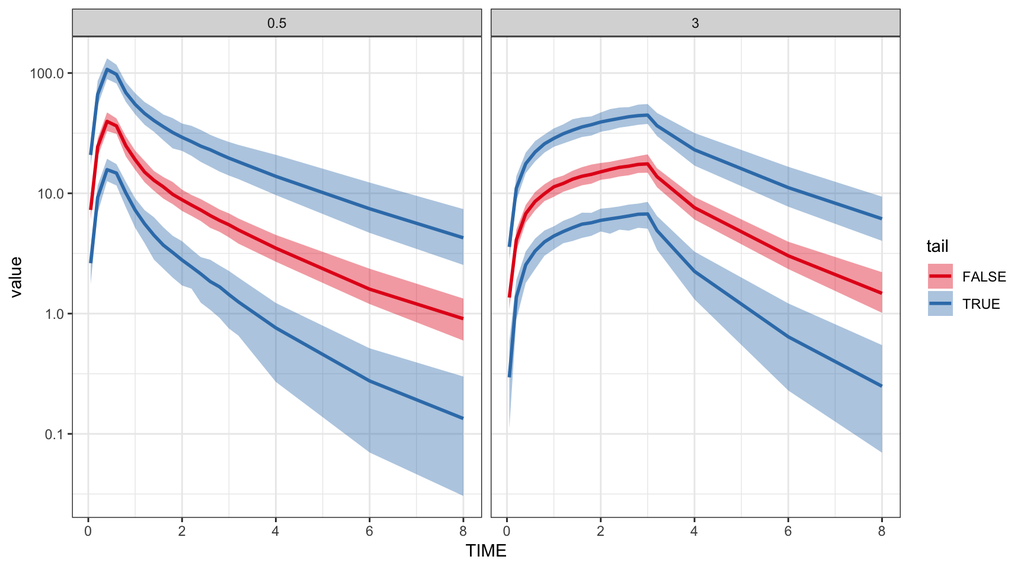

```r
rib <- filter(sum2l, stat %in% c("lo", "hi")) %>% spread(stat,value)
lin <- filter(sum2l, stat =="med")

p1 <-
  ggplot(rib, aes(x = TIME, group=metric))  +
  geom_ribbon(aes(ymin = lo, ymax = hi, fill=tail),alpha=0.4) +
  geom_line(data = lin, aes(y = value, col=tail), lwd=1) +
  facet_grid(~DUR) + scale_y_log10() + .fillSet1() + .colSet1(); p1
```

# 7 Summarize observed data and add to plot

```r
obs1 <-
  obs %>%
  filter(DV > 0) %>%
  group_by(DUR,TIME) %>%
  summarise(med=med(DV), lo=lo(DV), hi=hi(DV), N=n()) %>%
  gather(metric,value,med:hi)
```

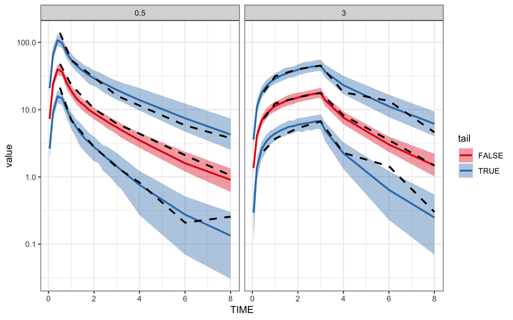

```r
p1 + geom_line(data=obs1, aes(TIME,value), lty=2, lwd=1)
```